# DATA612 Week 3 Project 3

Javern Wilson

June 24, 2019

When a user gives feed back or rate to a certain book that they read, this collection of feedback can be represented in a form of a matrix. Where each row represents each users, while each column represents different books. Obviously the matrix will be sparse since not everyone is going to read every book, due to different interests.

One strength of matrix factorization is the fact that it can incorporate implicit feedback, information that are not directly given but can be derived by analyzing user behavior. With this advantage, we can estimate and predict if a user is going to like a certain book that they never read. If that rating (assumed) is high, we can recommend that that book to the user.

One method, Singular Value Method is what will be used going forward in this project. Let there be matrix A $M \times N$. The matrix can be viewed as a dot product between two matrix with each matrices having dimensions of $M \times K$ and $K \times N$. One downside of SVD is that it does not work well with missing values.

```r
library(recommenderlab)
library(tidyverse)
library(kableExtra)
```

Review of how user-item books were created in [Project(2)](https://rpubs.com/javernw/jwDATA612wk2Proj2).

```r
book_ratings <- read.csv("https://raw.githubusercontent.com/zygmuntz/goodbooks-10k/master/ratings.csv", sep = ",", header = T, stringsAsFactors = F)

book_titles <- read.csv("https://raw.githubusercontent.com/zygmuntz/goodbooks-10k/master/books.csv", sep = ",", header = T, stringsAsFactors = F) %>% select(book_id, title)

book_titles$book_id <- as.factor(book_titles$book_id)
book_ratings$user_id <- as.factor(book_ratings$user_id)
book_ratings$book_id <- as.factor(book_ratings$book_id)

bmatrix <- as(book_ratings, "realRatingMatrix")
bmatrix <- bmatrix[rowCounts(bmatrix) > 150, colCounts(bmatrix) > 300]
bmatrix
```

```
## 4011 x 4147 rating matrix of class 'realRatingMatrix' with 582842 ratings.
```

#### Training and Test Sets

```r
## min(rowCounts(bmatrix)) = 75 so we can keep 25 items per user
bmat_eval <- evaluationScheme(data = bmatrix, method = "split", train = 0.8, given = 25, goodRating = 3, k = 1)
```

Let’s see how the different sets are in the evalution

```r
eval_train <- getData(bmat_eval, "train") #train
eval_train
```

```
## 3208 x 4147 rating matrix of class 'realRatingMatrix' with 465786 ratings.
```

```r
eval_known <- getData(bmat_eval, "known") # test data that we know
eval_known
```

```
## 803 x 4147 rating matrix of class 'realRatingMatrix' with 20075 ratings.
```

```r
eval_unknown <- getData(bmat_eval, "unknown")#test data that we do not know
eval_unknown
```

```
## 803 x 4147 rating matrix of class 'realRatingMatrix' with 96981 ratings.
```

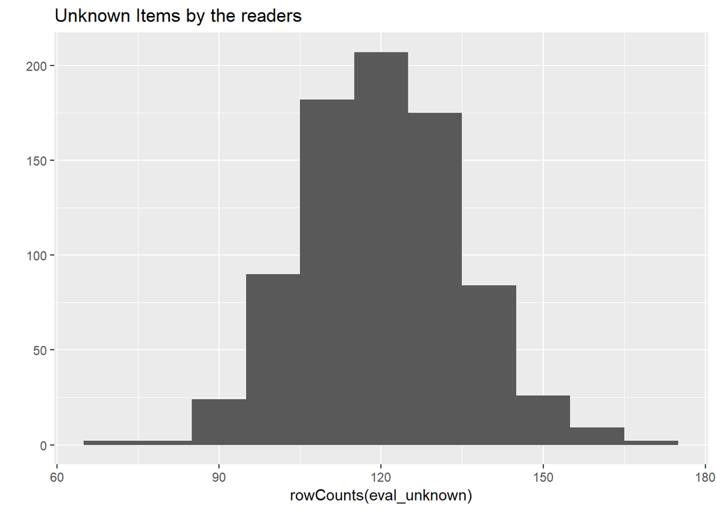

```r
qplot(rowCounts(eval_unknown)) + geom_histogram(binwidth = 10) + ggtitle("Unknown Items by the readers")
```

Evaluating the recommender system with SVD. Build recommender:

```r
system.time({

books_svd <- Recommender(data = getData(bmat_eval, "train"), method = "SVD")
})
```

```
##    user  system elapsed
##    2.35    0.39    2.82
```

```r
books_svd
```

```
## Recommender of type 'SVD' for 'realRatingMatrix'
## learned using 3208 users.
```

Compare it to IBCF

```r
system.time({
imodel <- Recommender(data = getData(bmat_eval, "train"), method = "IBCF")
})
```

```
##    user  system elapsed
##  609.10  305.67  915.74
```

```r
imodel
```

```
## Recommender of type 'IBCF' for 'realRatingMatrix'
## learned using 3208 users.
```

The SVD method is clearly faster.

#### Predict model

```r
#as topNlist
books_svd_pred <- predict(object = books_svd, newdata = eval_known, n = 10) %>% list()
books_svd_pred
```

```
## [[1]]
## Recommendations as 'topNList' with n = 10 for 803 users.
```

```r
#as real rating matrix
books_svd_pred_ <- predict(object = books_svd, newdata = eval_known, n = 10, type = "ratings")
books_svd_pred_
```

```
## 803 x 4147 rating matrix of class 'realRatingMatrix' with 3309966 ratings.
```

```r
#ibcf
booksibcf_pred <- predict(object = imodel, newdata = eval_known, n = 10, type = "ratings")
```

```r
svd_pred <- function(i){
p <- books_svd_pred[[1]]@ratings[[i]]
r <- data.frame("name" = as.factor(i))
r <- inner_join(r, book_titles, by = c("name" = "book_id")) %>% select(title)
print(paste("Ratings for --", r))
return(p)
}
```

Let’s pick some users and predict their ratings

```r
svd_pred(1)
```

```
## [1] "Ratings for -- The Hunger Games (The Hunger Games, #1)"
```

```
##  [1] 3.110284 3.100933 3.097932 3.096504 3.095380 3.095059 3.095027
##  [8] 3.093767 3.093691 3.093329
```

```r
svd_pred(5)
```

```
## [1] "Ratings for -- The Great Gatsby"
```

```
##  [1] 3.624007 3.603465 3.597189 3.561628 3.540180 3.536442 3.536245
##  [8] 3.517575 3.516860 3.501264
```

```r
svd_pred(200)
```

```
## [1] "Ratings for -- And Then There Were None"
```

```
##  [1] 4.037318 4.022901 4.019216 4.015127 4.013435 4.004952 3.939503
##  [8] 3.936291 3.932991 3.927677
```

```r
svd_pred(18)
```

```
## [1] "Ratings for -- Harry Potter and the Prisoner of Azkaban (Harry Potter, #3)"
```

```
##  [1] 3.822550 3.815094 3.808116 3.787699 3.783683 3.781402 3.780454
##  [8] 3.777911 3.773492 3.770998
```

```r
svd_pred(400)
```

```
## [1] "Ratings for -- Neuromancer"
```

```
##  [1] 3.685309 3.679514 3.676269 3.656057 3.588399 3.582025 3.580939
##  [8] 3.557832 3.551406 3.549157
```

#### To measure Accuracy

SVD

```r
eval_svd_pred <- calcPredictionAccuracy(x = books_svd_pred_, data = eval_unknown, byUser = TRUE)

kable(head(eval_svd_pred)) %>% kable_styling(bootstrap_options = "striped", font_size = 12, full_width = F)
```

|  | RMSE | MSE | MAE |
| --- | --- | --- | --- |
| 35 | 0.7990776 | 0.6385251 | 0.6067715 |
| 143 | 1.0108130 | 1.0217429 | 0.8559298 |
| 202 | 0.8055430 | 0.6488995 | 0.6614300 |
| 307 | 0.9705449 | 0.9419574 | 0.8277673 |
| 338 | 1.2079899 | 1.4592396 | 1.0824372 |
| 368 | 0.8609464 | 0.7412288 | 0.6116328 |

Item Based

```r
eval_ibcf_pred <- calcPredictionAccuracy(x = booksibcf_pred, data = eval_unknown, byUser = TRUE)

kable(head(eval_ibcf_pred)) %>% kable_styling(bootstrap_options = "striped", font_size = 12, full_width = F)
```

|  | RMSE | MSE | MAE |
| --- | --- | --- | --- |
| 35 | 1.0000000 | 1.000000 | 1.0000000 |
| 143 | 1.5118579 | 2.285714 | 1.4285714 |
| 202 | 0.8660254 | 0.750000 | 0.8333333 |
| 307 | 0.5000000 | 0.250000 | 0.2500000 |
| 338 | 0.7071068 | 0.500000 | 0.5000000 |
| 368 | 0.8660254 | 0.750000 | 0.7500000 |